# Análisis Geoespacial: Predio Chonchi

Zonificación Estratégica para Proyecto de Carbono (9,179 ha)

Pablo Cussen - Consultor en Proyectos de Carbono

28 de octubre de 2025

# 1 RESUMEN EJECUTIVO

## 1.1 Visión General

**Predio Chonchi** - Análisis para Proyecto de Carbono Forestal

**Ubicación:** Isla Grande de Chiloé, Región de Los Lagos, Chile  
**Área Total:** 9.179,01 hectáreas  
**Fecha de Análisis:** 28 de octubre de 2025

## 1.2 Métricas Principales

Bosque Maduro (IFM/Biochar)

6.333 ha

69% del predio

Área de Reforestación

254 ha

2.77% del predio

Zona de Protección

1.008 ha

10.98% del predio

Degradación Histórica

320 ha

4.8% del bosque histórico

## 1.3 Estado de Elegibilidad

**ELEGIBILIDAD CONFIRMADA** para proyectos de carbono bajo estándares Verra/Gold Standard

**Metodologías Aplicables:** - VM0034: Improved Forest Management (IFM) - AR-ACM0003: Afforestation and Reforestation - Producción de Biochar con secuestro permanente

# 2 ZONIFICACIÓN ESTRATÉGICA

## 2.1 Metodología de Zonificación

La zonificación se realizó mediante **álgebra de mapas** con criterios técnicos y de elegibilidad internacional:

**Zona 1: Biochar/IFM (Bosque Maduro)** - Cobertura arbórea **>60%** (año 2000) - Elegible para Improved Forest Management - Apto para producción de Biochar

**Zona 2: Reforestación** - Cobertura arbórea **<30%** (degradado) - Histórico de pérdida forestal documentada - **Exclusión:** Turberas, cuerpos de agua

**Zona 3: Protección** - Pendientes **>20°** (riesgo erosión) - Turberas/Sphagnum moss (SOC **>6,500 g/kg**) - Ocurrencia de agua **>90%**

## 2.2 Mapa de Zonificación

[figure not shown]

Figura 1: Zonificación estratégica del Predio Chonchi mostrando las tres áreas de manejo diferenciadas por color.

**Figura 1:** Mapa de zonificación estratégica. Verde oscuro: bosque maduro elegible para IFM/Biochar. Naranja: áreas degradadas para reforestación. Azul: zonas de protección (turberas, pendientes, agua). Gris: áreas intermedias sin asignación específica.

## 2.3 Distribución de Áreas

**Tabla 1:** Distribución cuantitativa de áreas por zona de manejo

| Zona de Manejo | Hectáreas | % del Predio |
| --- | --- | --- |
| Zona 1: IFM/Biochar | 6.333,30 | 69.00% |
| Sin Asignar | 1.666,14 | 18.15% |
| Zona 3: Protección | 1.007,95 | 10.98% |
| Zona 2: Reforestación | 254,35 | 2.77% |

**Interpretación de Resultados:**

**Zona 1 (6.333 ha):** Constituye el componente principal del proyecto. Bosque maduro con alta biomasa, elegible para manejo forestal mejorado (IFM) y producción de biochar.

**Zona 2 (254 ha):** Áreas históricamente forestadas que sufrieron degradación. Coincide con la pérdida forestal documentada, confirmando elegibilidad para proyectos de reforestación.

**Zona 3 (1.008 ha):** Ecosistemas de alto valor ecológico que requieren protección. Incluye turberas/Sphagnum moss (almacenes críticos de carbono) y zonas con restricciones topográficas.

# 3 DEGRADACIÓN HISTÓRICA

## 3.1 Pérdida Forestal (2000-2023)

Análisis basado en el dataset **Hansen Global Forest Change v1.11** procesado en Google Earth Engine:

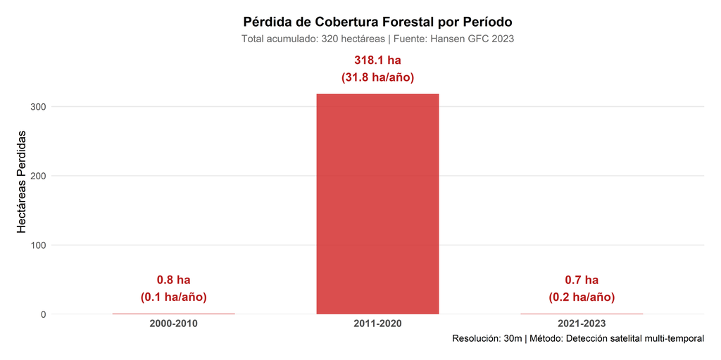

**Figura 2:** Pérdida forestal acumulada por período. El 99.5% de la degradación ocurrió entre 2011-2020, con una tasa promedio de 31.8 ha/año.

## 3.2 Comparación con Bosque Histórico

**Análisis Correcto de Degradación**

La degradación histórica debe compararse con el **área de bosque histórico**, no con el predio total:

- **Bosque actual (Zona 1):** 6.333,3 ha
- **Pérdida histórica (2000-2023):** 319,68 ha
- **Bosque histórico (año 2000):** 6.652,98 ha

**Degradación:** 4.8% del bosque histórico  
**% del predio total:** 3.48%

**Conclusión:** El predio ha experimentado una **pérdida neta de 320 hectáreas** de cobertura forestal entre 2000-2023, representando el **4.8%** de su bosque histórico. Esta degradación documentada confirma la elegibilidad para proyectos de **restauración ecosistémica** bajo VM0010.

# 4 TENDENCIA DE VEGETACIÓN (NDVI)

## 4.1 Serie Temporal 2018-2024